# Loan Prediction with ‘mlr’ pacakge

Kyu Cho

October 7, 2016

# Introduction

Dream Housing Finance company deals in all home loans. They have presence across all urban, semi urban and rural areas. Customer first apply for home loan after that company validates the customer eligibility for loan. Problem

Company wants to automate the loan eligibility process (real time) based on customer detail provided while filling online application form. These details are Gender, Marital Status, Education, Number of Dependents, Income, Loan Amount, Credit History and others. To automate this process, they have given a problem to identify the customers segments, those are eligible for loan amount so that they can specifically target these customers.

# Variables

- Variable=Description
- Loan_ID=Unique Loan ID
- Gender=Male/ Female
- Married=Applicant married (Y/N)
- Dependents=Number of dependents
- Education=Applicant Education (Graduate/ Under Graduate)
- Self_Employed=Self employed (Y/N)
- ApplicantIncome=Applicant income
- CoapplicantIncome=Coapplicant income
- LoanAmount=Loan amount in thousands
- Loan_Amount_Term=Term of loan in months
- Credit_History=credit history meets guidelines
- Property_Area=Urban/ Semi Urban/ Rural
- Loan_Status=Loan approved (Y/N)

# Table of Contents

1. Getting Data
2. Exploring Data
3. Missing Value Imputation
4. Feature Engineering
   - Outlier Removal by Capping
   - New Features
5. Machine Learning
   - Feature Importance
   - QDA
   - Logistic Regression
     - Cross Validation
   - Decision Tree
     - Cross Validation
     - Parameter Tuning using Grid Search
   - Random Forest
   - SVM
   - GBM (Gradient Boosting)
     - Cross Validation
     - Parameter Tuning using Random Search (Faster)
   - XGBoost (Extreme Gradient Boosting)
   - Feature Selection

# Intro

‘mlr’ package has - Regression - Classification - Clustering - Survival - Multiclassification - Cost sensitive classification

```r
library(mlr)
listLearners("classif")[c("class", "package")]
```

```
##                   class      package
## 1        classif.avNNet         nnet
## 2      classif.binomial        stats
## 3       classif.gausspr      kernlab
## 4           classif.gbm          gbm
## 5           classif.IBk        RWeka
## 6           classif.J48        RWeka
## 7          classif.JRip        RWeka
## 8           classif.knn        class
## 9          classif.ksvm      kernlab
## 10          classif.lda         MASS
## 11       classif.logreg        stats
## 12        classif.lssvm      kernlab
## 13         classif.lvq1        class
## 14     classif.multinom         nnet
## 15   classif.naiveBayes        e1071
## 16         classif.nnet         nnet
## 17         classif.OneR        RWeka
## 18         classif.PART        RWeka
## 19   classif.plsdaCaret        caret
## 20       classif.probit        stats
## 21          classif.qda         MASS
## 22 classif.randomForest randomForest
## 23        classif.rpart        rpart
## 24          classif.svm        e1071
## 25      classif.xgboost      xgboost
```

# Getting Data

```r
path <- "C:/Users/Kyu/Google Drive/Portfolio/project 102"
setwd(path)

train <- read.csv("train.csv", na.strings=c("", " ", NA))
test <- read.csv("test.csv", na.strings=c("", " ", NA))
```

# Exploring Data

```r
summarizeColumns(train)
```

```
##                 name    type na         mean         disp median       mad
## 1            Loan_ID  factor  0           NA    0.9983713     NA        NA
## 2             Gender  factor 13           NA           NA     NA        NA
## 3            Married  factor  3           NA           NA     NA        NA
## 4         Dependents  factor 15           NA           NA     NA        NA
## 5          Education  factor  0           NA    0.2182410     NA        NA
## 6      Self_Employed  factor 32           NA           NA     NA        NA
## 7    ApplicantIncome integer  0 5403.4592834 6109.0416734 3812.5 1822.8567
## 8  CoapplicantIncome numeric  0 1621.2457980 2926.2483692 1188.5 1762.0701
## 9         LoanAmount integer 22  146.4121622   85.5873252  128.0   47.4432
## 10  Loan_Amount_Term integer 14  342.0000000   65.1204099  360.0    0.0000
## 11    Credit_History integer 50    0.8421986    0.3648783    1.0    0.0000
## 12     Property_Area  factor  0           NA    0.6205212     NA        NA
## 13       Loan_Status  factor  0           NA    0.3127036     NA        NA
##    min   max nlevs
## 1    1     1   614
## 2  112   489     2
## 3  213   398     2
## 4   51   345     4
## 5  134   480     2
## 6   82   500     2
## 7  150 81000     0
## 8    0 41667     0
## 9    9   700     0
## 10  12   480     0
## 11   0     1     0
## 12 179   233     3
## 13 192   422     2
```

```r
summarizeColumns(test)
```

```
##                 name    type na         mean         disp median       mad
## 1            Loan_ID  factor  0           NA    0.9972752     NA        NA
## 2             Gender  factor 11           NA           NA     NA        NA
## 3            Married  factor  0           NA    0.3651226     NA        NA
## 4         Dependents  factor 10           NA           NA     NA        NA
## 5          Education  factor  0           NA    0.2288828     NA        NA
## 6      Self_Employed  factor 23           NA           NA     NA        NA
## 7    ApplicantIncome integer  0 4805.5994550 4910.6853990   3786 1598.2428
## 8  CoapplicantIncome integer  0 1569.5776567 2334.2320987   1025 1519.6650
## 9         LoanAmount integer  5  136.1325967   61.3666524    125   38.5476
## 10  Loan_Amount_Term integer  6  342.5373961   65.1566434    360    0.0000
## 11    Credit_History integer 29    0.8254438    0.3801498      1    0.0000
## 12     Property_Area  factor  0           NA    0.6185286     NA        NA
##    min   max nlevs
## 1    1     1   367
## 2   70   286     2
## 3  134   233     2
## 4   40   200     4
## 5   84   283     2
## 6   37   307     2
## 7    0 72529     0
## 8    0 24000     0
## 9   28   550     0
## 10   6   480     0
## 11   0     1     0
## 12 111   140     3
```

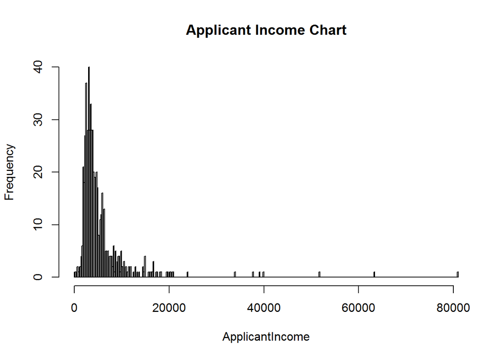

```r
# chekcing Skewness
hist(train$ApplicantIncome, breaks=300, main="Applicant Income Chart", xlab="ApplicantIncome")
```

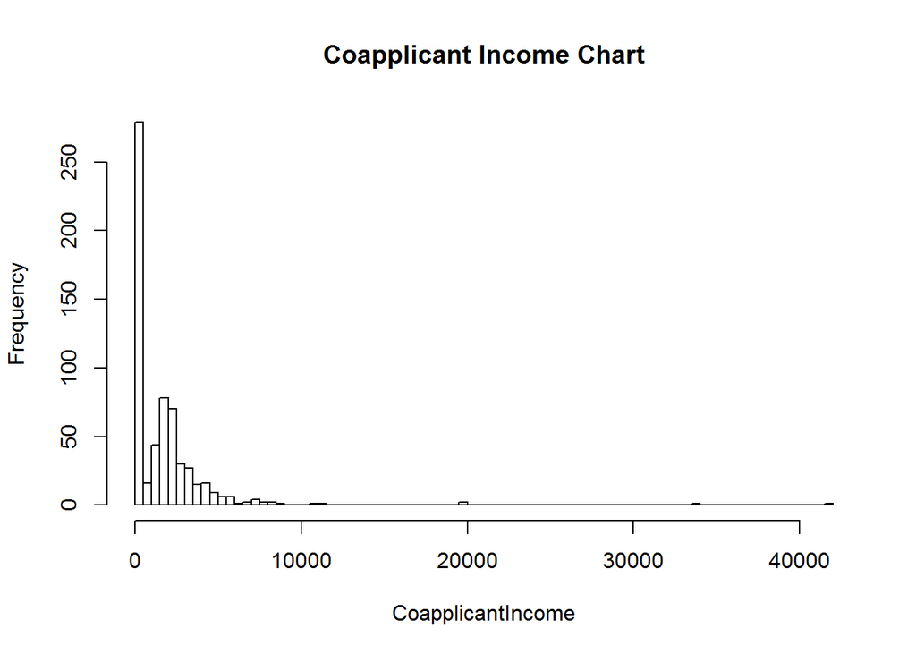

```r
hist(train$CoapplicantIncome, breaks=100, main="Coapplicant Income Chart", xlab="CoapplicantIncome")
```

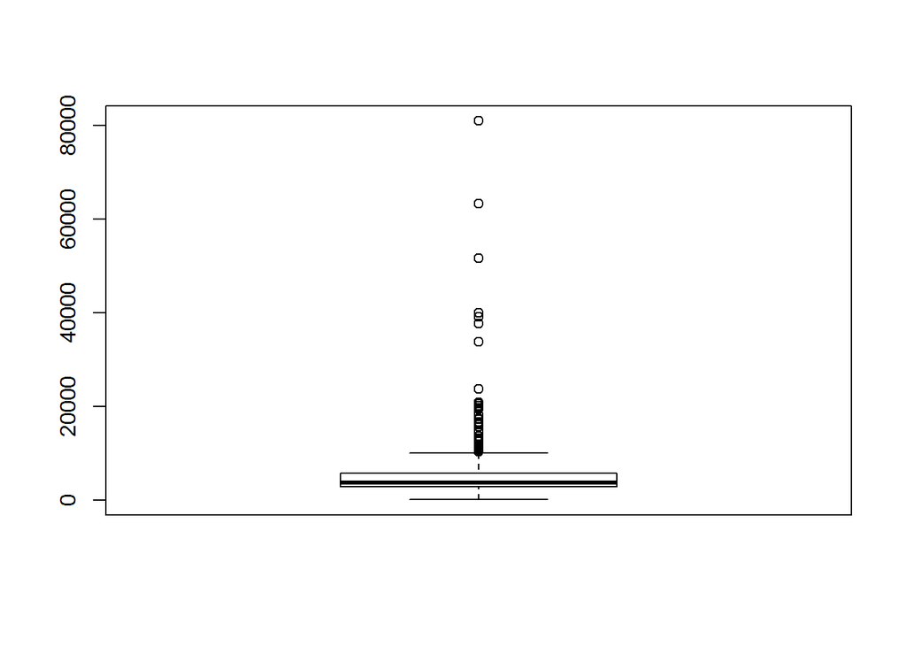

```r
# checking outliers
boxplot(train$ApplicantIncome)
```

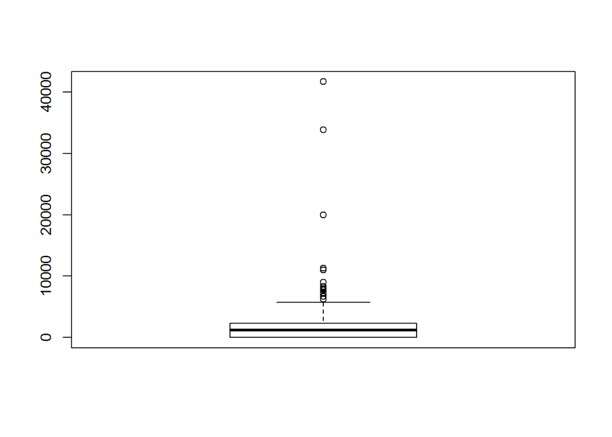

```r
boxplot(train$CoapplicantIncome)
```

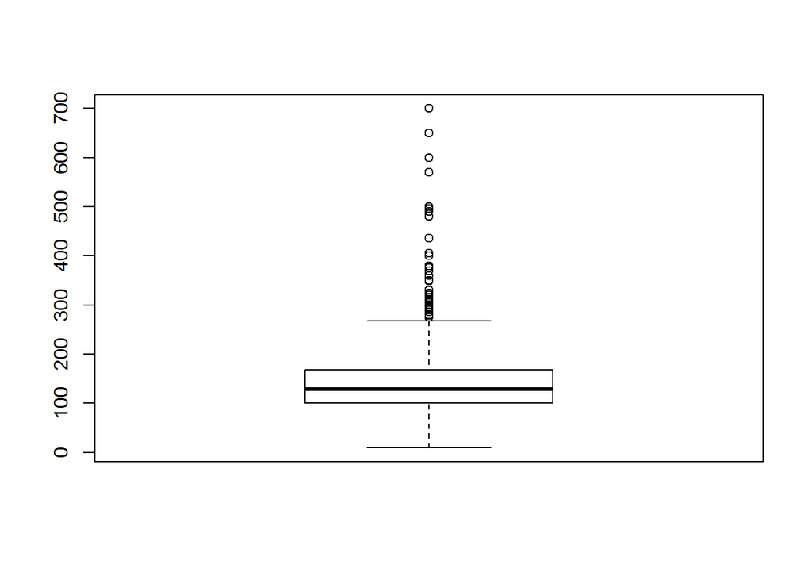

```r
boxplot(train$LoanAmount)
```

```r
# change the class of Credit_History to factor.
train$Credit_History <- as.factor(train$Credit_History)
test$Credit_History <- as.factor(test$Credit_History)

# rename level of Dependents "3+" to "3"
levels(train$Dependents)[4] <- "3"
levels(test$Dependents)[4] <- "3"
```

# Missing Value Imputation

```r
# impute missing values by mean and mode
imp <- impute(train, classes=list(factor=imputeMode(), integer=imputeMean()), dummy.classes=c("integer", "factor"), dummy.type="numeric")
imp1 <- impute(test, classes=list(factor=imputeMode(), integer=imputeMean()), dummy.classes=c("integer", "factor"), dummy.type="numeric")
```

Input function - It selects variables on the basis of their classes. - It creates new dummy variables for missing values. Sometimes, these (dummy) features contain a trend which can be captured using this function. - dummy.classes says for which classes should I create a dummy variable. - dummy.type says what should be the class of new dummy variables.

```r
imp_train <- imp$data
imp_test <- imp1$data
summarizeColumns(imp_train)
```

```
##                      name    type na         mean         disp median
## 1                 Loan_ID  factor  0           NA 9.983713e-01     NA
## 2                  Gender  factor  0           NA 1.824104e-01     NA
## 3                 Married  factor  0           NA 3.469055e-01     NA
## 4              Dependents  factor  0           NA 4.136808e-01     NA
## 5               Education  factor  0           NA 2.182410e-01     NA
## 6           Self_Employed  factor  0           NA 1.335505e-01     NA
## 7         ApplicantIncome numeric  0 5.403459e+03 6.109042e+03 3812.5
## 8       CoapplicantIncome numeric  0 1.621246e+03 2.926248e+03 1188.5
## 9              LoanAmount numeric  0 1.464122e+02 8.403747e+01  129.0
## 10       Loan_Amount_Term numeric  0 3.420000e+02 6.437249e+01  360.0
## 11         Credit_History  factor  0           NA 1.449511e-01     NA
## 12          Property_Area  factor  0           NA 6.205212e-01     NA
## 13            Loan_Status  factor  0           NA 3.127036e-01     NA
## 14           Gender.dummy numeric  0 2.117264e-02 1.440769e-01    0.0
```

[output cut: 27 more lines]

```r
summarizeColumns(imp_test)
```

```
##                      name    type na         mean         disp median
## 1                 Loan_ID  factor  0           NA    0.9972752     NA
## 2                  Gender  factor  0           NA    0.1907357     NA
## 3                 Married  factor  0           NA    0.3651226     NA
## 4              Dependents  factor  0           NA    0.4277929     NA
## 5               Education  factor  0           NA    0.2288828     NA
## 6           Self_Employed  factor  0           NA    0.1008174     NA
## 7         ApplicantIncome numeric  0 4.805599e+03 4910.6853990   3786
## 8       CoapplicantIncome numeric  0 1.569578e+03 2334.2320987   1025
## 9              LoanAmount numeric  0 1.361326e+02   60.9460398    126
## 10       Loan_Amount_Term numeric  0 3.425374e+02   64.6203656    360
## 11         Credit_History  factor  0           NA    0.1607629     NA
## 12          Property_Area  factor  0           NA    0.6185286     NA
## 13           Gender.dummy numeric  0 2.997275e-02    0.1707449      0
## 14       Dependents.dummy numeric  0 2.724796e-02    0.1630274      0
```

[output cut: 23 more lines]

Married.dummy variable exists only in imp_train and not in imp_test. - Remove it before modeling stage.

```r
# # impute with rpart
# rpart_imp <- impute(train, target="Loan_Status",
#                     classes=list(numeric=imputeLearner(makeLearner("regr.rpart")), factor=imputeLearner(makeLearner("classif.rpart"))),
#                     dummy.classes=c("numeric", "factor"),
#                     dummy.type="numeric")
```

# Feature Engineering

## Outlier Removal by Capping

```r
# remove outliers from variables
# threshold=MAX
cd <- capLargeValues(imp_train, target="Loan_Status", cols=c("ApplicantIncome"), threshold=40000)
cd <- capLargeValues(cd, target="Loan_Status", cols=c("CoapplicantIncome"), threshold=21000)
cd <- capLargeValues(cd, target="Loan_Status", cols=c("LoanAmount"), threshold=20)

# rename the train data as cd_train
cd_train <- cd

# add a dummy Loan_Status column in test data
imp_test$Loan_Status <- sample(0:1, size=367, replace=T)

cde <- capLargeValues(imp_test, target="Loan_Status", cols=c("ApplicantIncome"), threshold=33000)
cde <- capLargeValues(cde, target="Loan_Status", cols=c("CoapplicantIncome"), threshold=16000)
cde <- capLargeValues(cde, target="Loan_Status", cols=c("LoanAmount"), threshold=470)

# renaming test data
cd_test <- cde
```

```r
# dummy variables into categorical variables
for (f in names(cd_train[, c(14:20)])) {
    if( class(cd_train[, c(14:20)] [[f]]) == "numeric"){
        levels <- unique(cd_train[, c(14:20)][[f]])
        cd_train[, c(14:20)][[f]] <- as.factor(factor(cd_train[, c(14:20)][[f]], levels=levels))
        }
}

# convert numeric to factor - test
for (f in names(cd_test[, c(13:18)])) {
    if( class(cd_test[, c(13:18)] [[f]]) == "numeric"){
        levels <- unique(cd_test[, c(13:18)][[f]])
        cd_test[, c(13:18)][[f]] <- as.factor(factor(cd_test[, c(13:18)][[f]], levels=levels))
        }
}
```

These loops say - ’for every column name which falls column number 14 to 20 of cd_train / cd_test data frame, if the class of those variables in numeric, take out the unique value from those columns as levels and convert them into a factor (categorical) variables.

## New Features

```r
# Total_Income
cd_train$Total_Income <- cd_train$ApplicantIncome + cd_train$CoapplicantIncome
cd_test$Total_Income <- cd_test$ApplicantIncome + cd_test$CoapplicantIncome

# Income by loan
cd_train$Income_by_loan <- cd_train$Total_Income/cd_train$LoanAmount
cd_test$Income_by_loan <- cd_test$Total_Income/cd_test$LoanAmount

# change variable class
cd_train$Loan_Amount_Term <- as.numeric(cd_train$Loan_Amount_Term)
cd_test$Loan_Amount_Term <- as.numeric(cd_test$Loan_Amount_Term)

# Loan amount by term
cd_train$Loan_amount_by_term <- cd_train$LoanAmount/cd_train$Loan_Amount_Term
cd_test$Loan_amount_by_term <- cd_test$LoanAmount/cd_test$Loan_Amount_Term
```

New variables must be uncorrelated with existing variables - check the correlation

```r
# splitting the data based on class
az <- split(names(cd_train), sapply(cd_train, function(x){ class(x)}))

# creating a data frame of numeric variables
xs <- cd_train[az$numeric]

# check correlation
cor(xs)
```

```
##                     ApplicantIncome CoapplicantIncome LoanAmount
## ApplicantIncome         1.000000000       -0.14117527 0.03119924
## CoapplicantIncome      -0.141175270        1.00000000 0.02830556
## LoanAmount              0.031199236        0.02830556 1.00000000
## Loan_Amount_Term       -0.037457793       -0.04086784 0.02578562
## Total_Income            0.895278668        0.31465345 0.04265201
## Income_by_loan          0.895213188        0.31421615 0.02004914
## Loan_amount_by_term    -0.005661151        0.01719205 0.01085004
##                     Loan_Amount_Term Total_Income Income_by_loan
## ApplicantIncome          -0.03745779   0.89527867    0.895213188
## CoapplicantIncome        -0.04086784   0.31465345    0.314216147
## LoanAmount                0.02578562   0.04265201    0.020049143
## Loan_Amount_Term          1.00000000  -0.05430597   -0.054541127
## Total_Income             -0.05430597   1.00000000    0.999740426
## Income_by_loan           -0.05454113   0.99974043    1.000000000
## Loan_amount_by_term      -0.56917967   0.00230869    0.001940076
##                     Loan_amount_by_term
## ApplicantIncome            -0.005661151
## CoapplicantIncome           0.017192046
## LoanAmount                  0.010850042
## Loan_Amount_Term           -0.569179667
## Total_Income                0.002308690
## Income_by_loan              0.001940076
## Loan_amount_by_term         1.000000000
```

```r
# new variable has high correlation, so remove them
cd_train$Total_Income <- NULL
cd_test$Total_Income <- NULL

summarizeColumns(cd_train)
```

```
##                      name    type na         mean         disp
## 1                 Loan_ID  factor  0           NA 9.983713e-01
## 2                  Gender  factor  0           NA 1.824104e-01
## 3                 Married  factor  0           NA 3.469055e-01
## 4              Dependents  factor  0           NA 4.136808e-01
## 5               Education  factor  0           NA 2.182410e-01
## 6           Self_Employed  factor  0           NA 1.335505e-01
## 7         ApplicantIncome numeric  0 5.279518e+03 4.985851e+03
## 8       CoapplicantIncome numeric  0 1.566679e+03 2.340091e+03
## 9              LoanAmount numeric  0 1.997720e+01 4.599468e-01
## 10       Loan_Amount_Term numeric  0 3.420000e+02 6.437249e+01
## 11         Credit_History  factor  0           NA 1.449511e-01
## 12          Property_Area  factor  0           NA 6.205212e-01
## 13            Loan_Status  factor  0           NA 3.127036e-01
## 14           Gender.dummy  factor  0           NA 2.117264e-02
```

[output cut: 31 more lines]

```r
summarizeColumns(cd_test)
```

[output not shown]

[output cut: 31 more lines]

TODO - Keep create new features then correlation check

# Machine Learning

```r
# create a task
trainTask <- makeClassifTask(data=cd_train, target="Loan_Status", positive="Y")

# selecting top 6 important features
set.seed(1)
trainTask <- filterFeatures(trainTask, method="rf.importance", abs=6)

cd_test <- cd_test[, c("ApplicantIncome", "CoapplicantIncome", "Credit_History", "Property_Area", "Income_by_loan","Married", "Loan_Status")]
testTask <- makeClassifTask(data=cd_test, target="Loan_Status")

# normalize the variables
trainTask <- normalizeFeatures(trainTask, method="standardize")
testTask <- normalizeFeatures(testTask, method="standardize")

# remove the variables which are not required.
# trainTask <- dropFeatures(task=trainTask, features=c("Loan_ID", "Married.dummy"))

str(getTaskData(trainTask))
```

```
## 'data.frame':    614 obs. of  7 variables:
##  $ Married          : Factor w/ 2 levels "No","Yes": 1 2 2 2 1 2 2 2 2 2 ...
##  $ ApplicantIncome  : num  0.114 -0.14 -0.457 -0.541 0.145 ...
##  $ CoapplicantIncome: num  -0.6695 -0.0251 -0.6695 0.3382 -0.6695 ...
##  $ Credit_History   : Factor w/ 2 levels "0","1": 2 2 2 2 2 2 2 1 2 2 ...
##  $ Property_Area    : Factor w/ 3 levels "Rural","Semiurban",..: 3 1 3 3 3 3 3 2 3 2 ...
##  $ Income_by_loan   : num  -0.193 -0.146 -0.741 -0.368 -0.164 ...
##  $ Loan_Status      : Factor w/ 2 levels "N","Y": 2 1 2 2 2 2 2 1 2 1 ...
```

```r
str(getTaskData(testTask))
```

[output not shown]

## Feature Importance

[figure not shown]

```r
#Feature importance
im_feat <- generateFilterValuesData(trainTask, method=c("information.gain", "chi.squared"))
plotFilterValues(im_feat, n.show=20)
```

```r
# to launch its shiny application
# plotFilterValuesGGVIS(im_feat)
```

## QDA

qda is a parametric algorithm which makes certain assumptions about data.  
If the data is actually found to follow the assumptions, such algorithms sometime outperform several non-parametric algorithms.

```r
# load qda
qda.learner <- makeLearner("classif.qda", predict.type="response")

# train model
qmodel <- train(qda.learner, trainTask)

# predict on test data
qpredict <- predict(qmodel, testTask)
#
# # create submission file
# submit <- data.frame(Loan_ID=test$Loan_ID, Loan_Status=qpredict$data$response)
# write.csv(submit, "submit1.csv", row.names=F)
```

## Logistic Regression

### Cross Validation

```r
# logistic regression
logistic.learner <- makeLearner("classif.logreg", predict.type="response")

# cross validation (cv) accuracy
cv.logistic <- crossval(learner=logistic.learner, task=trainTask, iters=3, stratify=TRUE, measures=acc, show.info=F)
```

```r
# cross validation accuracy
cv.logistic$aggr
```

```
## acc.test.mean
##     0.8094612
```

```r
cv.logistic$measures.test
```

```
##   iter       acc
## 1    1 0.8341463
## 2    2 0.8186275
## 3    3 0.7756098
```

```r
# train model
fmodel <- train(logistic.learner, trainTask)
getLearnerModel(fmodel)
```

```
##
## Call:  stats::glm(formula = f, family = "binomial", data = getTaskData(.task,
##     .subset), weights = .weights, model = FALSE)
##
## Coefficients:
##            (Intercept)              MarriedYes         ApplicantIncome
##                -3.2984                  0.5495                  6.9933
##      CoapplicantIncome         Credit_History1  Property_AreaSemiurban
##                 3.1618                  3.9002                  0.9031
##     Property_AreaUrban          Income_by_loan
##                 0.2612                 -7.3212
##
## Degrees of Freedom: 613 Total (i.e. Null);  606 Residual
## Null Deviance:       762.9
## Residual Deviance: 564.6     AIC: 580.6
```

```r
# predict on test data
fpmodel <- predict(fmodel, testTask)

# #create submission file
# submit <- data.frame(Loan_ID=test$Loan_ID, Loan_Status=fpmodel$data$response)
# write.csv(submit, "submit2.csv", row.names=F)
```

## Decision Tree

### Cross Validation

```r
getParamSet("classif.rpart")

# make tree learner
makeatree <- makeLearner("classif.rpart", predict.type="response")

# set 3 fold cross validation
set_cv <- makeResampleDesc("CV", iters=3L)

# Search for hyperparameters
gs <- makeParamSet(makeIntegerParam("minsplit", lower=10, upper=50),
                   makeIntegerParam("minbucket", lower=5, upper=50),
                   makeNumericParam("cp", lower=0.001, upper=0.2))

# grid search
gscontrol <- makeTuneControlGrid()

# hypertune the parameters
stune <- tuneParams(learner=makeatree,
                    resampling=set_cv,
                    task=trainTask,
                    par.set=gs,
                    control=gscontrol,
                    measures=acc)
```

```r
# check best parameter
stune$x
```

```
## $minsplit
## [1] 41
##
## $minbucket
## [1] 30
##
## $cp
## [1] 0.001
```

```r
# cross validation result
stune$y
```

```
## acc.test.mean
##     0.8093815
```

### Bulid Model

```r
# using hyperparameters for modeling
t.tree <- setHyperPars(makeatree, par.vals=stune$x)

# train the model
t.rpart <- train(t.tree, trainTask)
getLearnerModel(t.rpart)
```

```
## n= 614
##
## node), split, n, loss, yval, (yprob)
##       * denotes terminal node
##
## 1) root 614 192 Y (0.31270358 0.68729642)
##   2) Credit_History=0 89   7 N (0.92134831 0.07865169) *
##   3) Credit_History=1 525 110 Y (0.20952381 0.79047619) *
```

```r
# make predictions
tpmodel <- predict(t.rpart, testTask)

# # create a submission file
# submit <- data.frame(Loan_ID=test$Loan_ID, Loan_Status=tpmodel$data$response)
# write.csv(submit, "submit3.csv", row.names=F)
```

Set 3 parameters.  
- minsplit : the minimum number of observation in a node for a split to take place.  
- minbucket : the minimum number of observation in terminal nodes.  
- cp : the complexity parameter. The lesser it is, more in overfitting.

## Random Forest

Random Forest’s prediction derive from an ensemble of trees. It averages the prediction given by each tree and produces a generalized result. This time I’ve done random search instead of grid search for parameter tuning, because it’s faster.

### Cross Validation

```r
getParamSet("classif.randomForest")

# create a learner
rf <- makeLearner("classif.randomForest", predict.type="response", par.vals=list(ntree=200, mtry=3))
rf$par.vals <- list(importance=TRUE)

# set tunable parameters
# grid search to find hyperparameters
rf_param <- makeParamSet(makeIntegerParam("ntree", lower=50, upper=500),
                         makeIntegerParam("mtry", lower=3, upper=10),
                         makeIntegerParam("nodesize", lower=10, upper=50))

#  random search for 50 iterations
rancontrol <- makeTuneControlRandom(maxit=50L)

# set 3 fold cross validation
set_cv <- makeResampleDesc("CV", iters=3L)

# hypertuning
rf_tune <- tuneParams(learner=rf, resampling=set_cv, task=trainTask, par.set=rf_param, control=rancontrol, measures=acc)
```

```r
#best parameters
rf_tune$x
```

```
## $ntree
## [1] 176
##
## $mtry
## [1] 3
##
## $nodesize
## [1] 37
```

```r
# cv accuracy
rf_tune$y
```

```
## acc.test.mean
##     0.8061852
```

### Build Model

```r
# using hyperparameters for modeling
rf.tree <- setHyperPars(rf, par.vals=rf_tune$x)

# train a model
rforest <- train(rf.tree, trainTask)
getLearnerModel(t.rpart)
```

```
## n= 614
##
## node), split, n, loss, yval, (yprob)
##       * denotes terminal node
##
## 1) root 614 192 Y (0.31270358 0.68729642)
##   2) Credit_History=0 89   7 N (0.92134831 0.07865169) *
##   3) Credit_History=1 525 110 Y (0.20952381 0.79047619) *
```

```r
# make predictions
rfmodel <- predict(rforest, testTask)

# # submission file
# submit <- data.frame(Loan_ID=test$Loan_ID, Loan_Status=rfmodel$data$response)
# write.csv(submit, "submit4.csv", row.names=F)
```

## SVM

SVM creates a hyperplane in n dimensional space to classify the data based on target class.

### Cross Validation

```r
# load svm
getParamSet("classif.ksvm") # install kernlab package
ksvm <- makeLearner("classif.ksvm", predict.type="response")

# Set parameters
pssvm <- makeParamSet(makeDiscreteParam("C", values=2^c(-8, -4, -2, 0)), # cost parameters
                      makeDiscreteParam("sigma", values=2^c(-8, -4, 0, 4))) # RBF Kernel Parameter

# specify search function
ctrl <- makeTuneControlGrid()

# tune model
res <- tuneParams(ksvm, task=trainTask, resampling=set_cv, par.set=pssvm, control=ctrl, measures=acc)
```

```r
# CV accuracy
res$y
```

```
## acc.test.mean
##     0.8110394
```

### Build Model

```r
#set the model with best params
t.svm <- setHyperPars(ksvm, par.vals=res$x)

#train
par.svm <- train(ksvm, trainTask)

#test
predict.svm <- predict(par.svm, testTask)

# #submission file
# submit <- data.frame(Loan_ID=test$Loan_ID, Loan_Status=predict.svm$data$response)
# write.csv(submit, "submit5.csv", row.names=F)
```

## GBM (Gradient Boosting)

GBM performs sequential modeling i.e after one round of prediction, it checks for incorrect predictions, assigns them relatively more weight and predict them again until they are predicted correctly.

### Cross Validation

```r
# load GBM
getParamSet("classif.gbm")
g.gbm <- makeLearner("classif.gbm", predict.type="response")

# specify tuning method
rancontrol <- makeTuneControlRandom(maxit=50L)

# 3 fold cross validation
set_cv <- makeResampleDesc("CV", iters=3L)

# parameters
gbm_par<- makeParamSet(makeDiscreteParam("distribution", values="bernoulli"),
                       makeIntegerParam("n.trees", lower=100, upper=1000), # number of trees
                       makeIntegerParam("interaction.depth", lower=2, upper=10), # depth of tree
                       makeIntegerParam("n.minobsinnode", lower=10, upper=80), # min # of observations in a node
                       makeNumericParam("shrinkage", lower=0.01, upper=1)) # ragulation param. which dictates how fast / slow the algorithm.

# tune parameters
tune_gbm <- tuneParams(learner=g.gbm, task=trainTask, resampling=set_cv, measures=acc, par.set=gbm_par, control=rancontrol)
```

```r
# check CV accuracy
tune_gbm$y
```

```
## acc.test.mean
##     0.7475132
```

### Build Model

```r
#set parameters
final_gbm <- setHyperPars(learner=g.gbm, par.vals=tune_gbm$x)

#train
to.gbm <- train(final_gbm, trainTask)

#test
pr.gbm <- predict(to.gbm, testTask)

# #submission file
# submit <- data.frame(Loan_ID=test$Loan_ID, Loan_Status=pr.gbm$data$response)
# write.csv(submit, "submit6.csv", row.names=F)
```

## XGBoost (Extreme Gradient Boosting)

- Xgboost is better than GBM due to its inbuilt properties including first and second order gradient, parallel processing and ability to prune trees.
- xgboost in ‘mlr’ packages does not requires matrix fomat input.

### Cross Validation

```r
# load xgboost
set.seed(1001)
getParamSet("classif.xgboost")

#make learner with inital parameters
xg_set <- makeLearner("classif.xgboost", predict.type="response")
xg_set$par.vals <- list(objective="binary:logistic", eval_metric="error", nrounds=250)

#define parameters for tuning
xg_ps <- makeParamSet(makeIntegerParam("nrounds", lower=200, upper=600),
                      makeIntegerParam("max_depth", lower=3, upper=20),
                      makeNumericParam("lambda", lower=0.55, upper=0.60),
                      makeNumericParam("eta", lower=0.001, upper=0.5),
                      makeNumericParam("subsample", lower=0.10, upper=0.80),
                      makeNumericParam("min_child_weight", lower=1, upper=5),
                      makeNumericParam("colsample_bytree", lower=0.2, upper=0.8))

# define search function
rancontrol <- makeTuneControlRandom(maxit=100L) #do 100 iterations

# 3 fold cross validation
set_cv <- makeResampleDesc("CV", iters=3L)

# tune parameters
xg_tune <- tuneParams(learner=xg_set, task=trainTask, resampling=set_cv, measures=acc, par.set=xg_ps, control=rancontrol)
```

```r
# accuracy
xg_tune$y
```

```
## acc.test.mean
##     0.8110713
```

### Build Model

```r
# set parameters
xg_new <- setHyperPars(learner=xg_set, par.vals=xg_tune$x)

# train model
xgmodel <- train(xg_new, trainTask)

# test model
predict.xg <- predict(xgmodel, testTask)

# # submission file
# submit <- data.frame(Loan_ID=test$Loan_ID, Loan_Status=predict.xg$data$response)
# write.csv(submit, "submit7.csv", row.names=F)
```